# 2. Causal Inference

Edoardo Cortolezzis

2025-01-15

# Excercise 2: Causal inference

**Consider the dataset electric_wide.txt about the Electric Company example (you find the dataset in the Exam section in the Moodle page): for further details see the ROS book, Chapter 19.2, and lecture notes from slide 19.** ``

```r
# loading the dataset and preprocessing to be compatible with the CI models
data_electric <- read.table("datasets/electric_wide.txt", header = TRUE)
# preprocessing from the lab
post_test <- c(data_electric$treated_posttest, data_electric$control_posttest)
pre_test <- c(data_electric$treated_pretest, data_electric$control_pretest)
grade <- rep(data_electric$grade, 2)
treatment <- rep(c(1,0), rep(length(data_electric$treated_posttest),2))
supp <- rep(NA, length(data_electric$treatment))
n_pairs <- nrow(data_electric)
pair_id <- rep(1:n_pairs, 2)
supp[treatment==1] <- ifelse(data_electric$supplement=="Supplement", 1, 0)
n <- length(post_test)
electric <- data.frame(post_test, pre_test, grade, treatment, supp, pair_id)

str(electric)
```

```
## 'data.frame':    192 obs. of  6 variables:
##  $ post_test: num  48.9 70.5 89.7 44.2 77.5 84.7 78.9 86.8 60.8 75.7 ...
##  $ pre_test : num  13.8 16.5 18.5 8.8 15.3 15 19.4 15 11.8 16.4 ...
##  $ grade    : int  1 1 1 1 1 1 1 1 1 1 ...
##  $ treatment: num  1 1 1 1 1 1 1 1 1 1 ...
##  $ supp     : num  1 0 1 0 1 0 0 1 1 1 ...
##  $ pair_id  : int  1 2 3 4 5 6 7 8 9 10 ...
```

The dataset has 192 observations across 6 variables:

- *ppost_test*: score after the experiment;
- *pre_test*: score before the experiment;
- *grade level (grade)*: grade of the students on which the score was measured;
- *treatment*: wether the treatment was assigned or not;
- *supp*: status of the supplement;
- *pair_id*: pair identifier.

To better understand the data, we can start by looking at the relationship between pre and post test scores for each grade and with an indicator on the treatment group. For this purpose, we can create a scatter plots with a linear regression line `post_test ~ pre_test`.

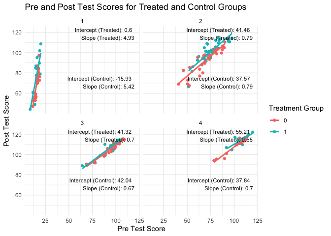

From these preliminary plots we can see that the lower the grade, the steeper the improvement (difference between pre and post-test scores). However, it’s not clear how impactful the treatment is on the improvement. For this reason, we’ll fit the following models: (6), (7) and (8).

## Fit the models (6), (7) and (8) from lecture notes from a Bayesian and a frequentist point of view, using rstanarm/rstan and lme4 packages.

### Model (6)

$$y_i = \alpha + \theta*z_i +
error_i$$
where:

- $y_i$ is the post-test score of the i-th student;
- $\alpha$ is the intercept (when no treatment is applied);
- $\theta$ is the treatment effect. Which is counted only for people in the treatment group (with $z_i = 1$), and is 0 for people in the control group (with $z_i = 0$).

```r
# Define the models lists to store the models
frequentist_models_6 <- list()
bayesian_models_6 <- list()

# Fit the models for each crime
for (i in 1:4){
  cat("Fitting models for grade", i, "\n")
  cat("Frequentist model\n")
  frequentist_models_6[[i]] <- lm(post_test ~ treatment,
                                data = electric[electric$grade == i,])

  cat("Bayesian model\n")
  bayesian_models_6[[i]] <- stan_glm(post_test ~ treatment,
                                   data = electric[electric$grade == i,],
                                   family = gaussian(),
                                   seed=42)
}
```

### Model (7)

$$y_i = \alpha + \theta*z_i + \beta*x_i +
error_i$$
where:

- …
- $\beta$ is the slope associated to the pre-test variable ($x_i$).

```r
# Define the models lists to store the models
frequentist_models_7 <- list()
bayesian_models_7 <- list()

# Fit the models for each crime
for (i in 1:4){
  cat("Fitting models for grade", i, "\n")
  cat("Frequentist model\n")
  frequentist_models_7[[i]] <- lm(post_test ~ treatment + pre_test,
                                data = electric[electric$grade == i,])

  cat("Bayesian model\n")
  bayesian_models_7[[i]] <- stan_glm(post_test ~ treatment + pre_test,
                                   data = electric[electric$grade == i,],
                                   family = gaussian(),
                                   seed=42)
}
```

### Model (8)

$$y_i = \alpha + \theta*z_i + \beta*x_i +
\tau*z_i*x_i + error_i$$
where:

- …
- $\tau$ is the slope associated to the pre-test variable ($x_i$) when the i-th observation has been assigned to the treatment group ($z_i = 1$).

```r
# Define the models lists to store the models
frequentist_models_8 <- list()
bayesian_models_8 <- list()

# Fit the models for each crime
for (i in 1:4){
  cat("Fitting models for grade", i, "\n")
  cat("Frequentist model\n")
  frequentist_models_8[[i]] <- lm(post_test ~ treatment * pre_test,
                                data = electric[electric$grade == i,])

  cat("Bayesian model\n")
  bayesian_models_8[[i]] <- stan_glm(post_test ~ treatment * pre_test,
                                   data = electric[electric$grade == i,],
                                   family = gaussian(),
                                   seed=42)
}
```

## Provide the estimates (also from a graphical perspective) and comment the results.

### Model (6)

- Estimates:

```
##
## ----------------
## Grade 1
## -- Frequentist
##
## Call:
## lm(formula = post_test ~ treatment, data = electric[electric$grade ==
##     i, ])
##
## Residuals:
##     Min      1Q  Median      3Q     Max
## -32.890 -13.190   2.060   7.685  31.510
##
## Coefficients:
##             Estimate Std. Error t value Pr(>|t|)
## (Intercept)   68.790      3.268  21.047   <2e-16 ***
## treatment      8.300      4.622   1.796   0.0801 .
## ---
## Signif. codes:  0 '***' 0.001 '**' 0.01 '*' 0.05 '.' 0.1 ' ' 1
##
## Residual standard error: 14.98 on 40 degrees of freedom
## Multiple R-squared:  0.0746, Adjusted R-squared:  0.05146
## F-statistic: 3.224 on 1 and 40 DF,  p-value: 0.0801
##
## -- Bayesian
##
## Model Info:
##  function:     stan_glm
##  family:       gaussian [identity]
##  formula:      post_test ~ treatment
##  algorithm:    sampling
##  sample:       4000 (posterior sample size)
##  priors:       see help('prior_summary')
##  observations: 42
##  predictors:   2
##
## Estimates:
##               mean   sd   10%   50%   90%
## (Intercept) 68.7    3.3 64.6  68.7  72.9
## treatment    8.3    4.7  2.4   8.3  14.2
```

[output cut: 173 more lines]

```
## Fit Diagnostics:
##            mean   sd    10%   50%   90%
## mean_PPD 112.2    1.4 110.5 112.2 114.0
##
## The mean_ppd is the sample average posterior predictive distribution of the outcome variable (for details see help('summary.stanreg')).
##
## MCMC diagnostics
##               mcse Rhat n_eff
## (Intercept)   0.0  1.0  3544
## treatment     0.0  1.0  4021
## sigma         0.0  1.0  3350
## mean_PPD      0.0  1.0  3879
## log-posterior 0.0  1.0  1798
##
## For each parameter, mcse is Monte Carlo standard error, n_eff is a crude measure of effective sample size, and Rhat is the potential scale reduction factor on split chains (at convergence Rhat=1).
```

- Plots:

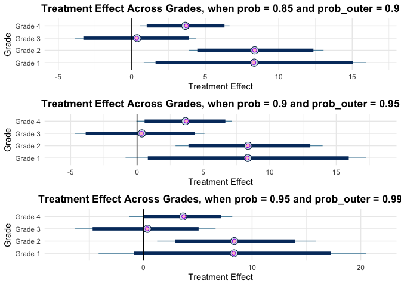

As we increase the confidence intervals (`prob` and `prob_outer`) of the `mcmc_intervals`, the treatment effect appears to remain significant primarily for lower grades. This finding aligns with the expectation that the treatment would have a greater impact on students with lower initial performance, as they have more potential for improvement. This is particularly evident in second-grade students, where we can confidently conclude a significant positive treatment effect on post-test scores.

We can even take a look at the predictions made by the model:

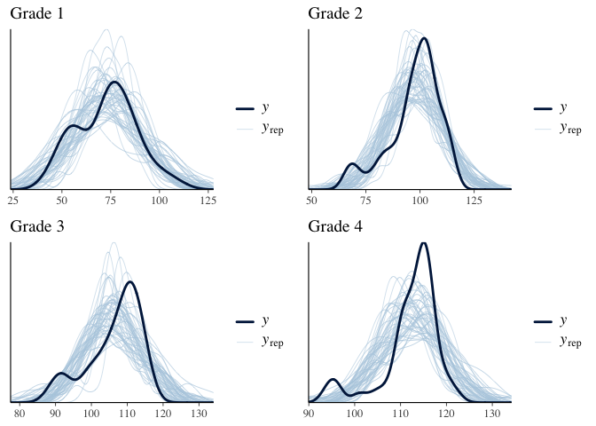

The model doesn’t seem to capture well the true distribution of post_score.

### Model (7)

- Estimates:

```
##
## ----------------
## Grade 1
## -- Frequentist
##
## Call:
## lm(formula = post_test ~ treatment + pre_test, data = electric[electric$grade ==
##     i, ])
##
## Residuals:
##     Min      1Q  Median      3Q     Max
## -19.360  -5.059   0.445   5.640  15.349
##
## Coefficients:
##             Estimate Std. Error t value Pr(>|t|)
## (Intercept) -11.0229     8.7860  -1.255  0.21709
## treatment     8.7865     2.6118   3.364  0.00173 **
## pre_test      5.1084     0.5498   9.292 1.96e-11 ***
## ---
## Signif. codes:  0 '***' 0.001 '**' 0.01 '*' 0.05 '.' 0.1 ' ' 1
##
## Residual standard error: 8.461 on 39 degrees of freedom
## Multiple R-squared:  0.712,  Adjusted R-squared:  0.6973
## F-statistic: 48.22 on 2 and 39 DF,  p-value: 2.863e-11
##
## -- Bayesian
##
## Model Info:
##  function:     stan_glm
##  family:       gaussian [identity]
##  formula:      post_test ~ treatment + pre_test
##  algorithm:    sampling
##  sample:       4000 (posterior sample size)
##  priors:       see help('prior_summary')
##  observations: 42
##  predictors:   3
##
## Estimates:
##               mean   sd    10%   50%   90%
## (Intercept) -10.6    9.3 -22.1 -10.7   1.3
```

[output cut: 185 more lines]

```
##            mean   sd    10%   50%   90%
## mean_PPD 112.2    0.5 111.6 112.2 112.9
##
## The mean_ppd is the sample average posterior predictive distribution of the outcome variable (for details see help('summary.stanreg')).
##
## MCMC diagnostics
##               mcse Rhat n_eff
## (Intercept)   0.1  1.0  4475
## treatment     0.0  1.0  4875
## pre_test      0.0  1.0  4463
## sigma         0.0  1.0  3725
## mean_PPD      0.0  1.0  3315
## log-posterior 0.0  1.0  1521
##
## For each parameter, mcse is Monte Carlo standard error, n_eff is a crude measure of effective sample size, and Rhat is the potential scale reduction factor on split chains (at convergence Rhat=1).
```

- Plots:

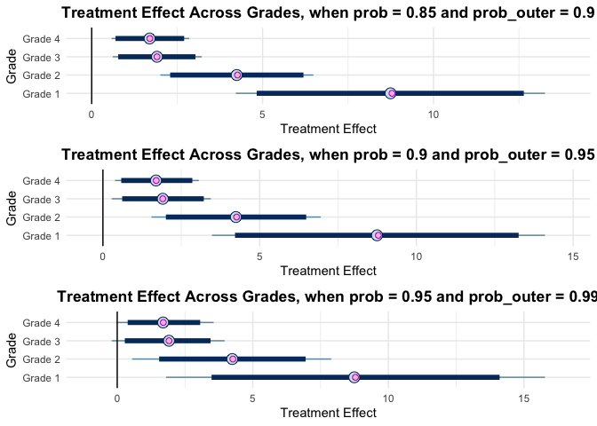

When considering even the pre-test scores, the treatment effect appears to diminish with increasing grade level. While a significant impact is observed for lower grades, the evidence for a treatment effect in grades 3 and 4 is more uncertain.

Predictions made by the model:

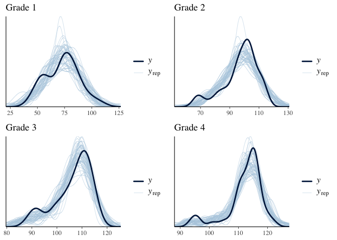

Model (7) shows some improvement in predictive performance compared to Model (6), but there is still potential for further refinements.

### Model (8)

- Estimate:

```
##
## ----------------
## Grade 1
## -- Frequentist
##
## Call:
## lm(formula = post_test ~ treatment * pre_test, data = electric[electric$grade ==
##     i, ])
##
## Residuals:
##      Min       1Q   Median       3Q      Max
## -19.6759  -5.2192   0.3025   5.9643  14.7022
##
## Coefficients:
##                    Estimate Std. Error t value Pr(>|t|)
## (Intercept)        -15.9258    14.4333  -1.103    0.277
## treatment           16.5255    18.1540   0.910    0.368
## pre_test             5.4223     0.9160   5.919 7.35e-07 ***
## treatment:pre_test  -0.4964     1.1522  -0.431    0.669
## ---
## Signif. codes:  0 '***' 0.001 '**' 0.01 '*' 0.05 '.' 0.1 ' ' 1
##
## Residual standard error: 8.551 on 38 degrees of freedom
## Multiple R-squared:  0.7134, Adjusted R-squared:  0.6908
## F-statistic: 31.54 on 3 and 38 DF,  p-value: 2.08e-10
##
## -- Bayesian
##
## Model Info:
##  function:     stan_glm
##  family:       gaussian [identity]
##  formula:      post_test ~ treatment * pre_test
##  algorithm:    sampling
##  sample:       4000 (posterior sample size)
##  priors:       see help('prior_summary')
##  observations: 42
##  predictors:   4
##
## Estimates:
##                      mean   sd    10%   50%   90%
```

[output cut: 197 more lines]

```
## mean_PPD 112.2    0.5 111.6 112.2 112.8
##
## The mean_ppd is the sample average posterior predictive distribution of the outcome variable (for details see help('summary.stanreg')).
##
## MCMC diagnostics
##                    mcse Rhat n_eff
## (Intercept)        0.1  1.0  1791
## treatment          0.2  1.0  1375
## pre_test           0.0  1.0  1775
## treatment:pre_test 0.0  1.0  1369
## sigma              0.0  1.0  2138
## mean_PPD           0.0  1.0  3119
## log-posterior      0.0  1.0  1302
##
## For each parameter, mcse is Monte Carlo standard error, n_eff is a crude measure of effective sample size, and Rhat is the potential scale reduction factor on split chains (at convergence Rhat=1).
```

- Plots:

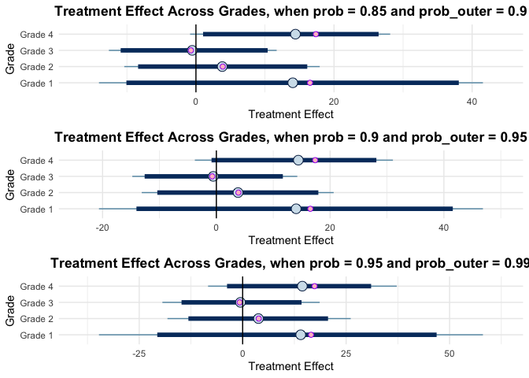

However, if we also consider the interaction between treatment and pre_test score, the impactful improvement we’ve seen in the previous models, seems to vanish even for lower grades.

Predictions made by the model:

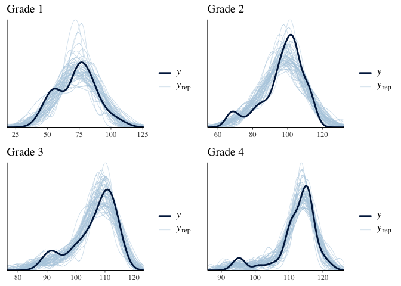

The model’s predictions exhibit high uncertainty, as evidenced by the wide confidence intervals on the treatment effect and the substantial spread in the predicted values.

## Write in formulas and fit a multilevel/hierarchical model on these data and compare the results with those previously obtained.

Starting from the model (7), we group observations by grade and design a multilevel model with a random intercept and slop for each grade and pre_test.
$$y_{i} = \alpha_j + \theta_j z_{i
} + \beta_j x_{i} + \text{error}_{ij}$$

where: - $i$ indexes individual level observations and $j$ indexes the groups (grades in this case); - $\alpha_j$ is the group-specific intercept for grade $j$; - $\theta_j$ is the effect of treatment for grade $j$; - $z_{i}$ = 1 if the observation $i$ in grade $j$ is in the treatment group, 0 otherwise; - $\beta_j$ is the effect of the pre-test score ($x_{i}$) for grade $j$; - $\text{error}_{ij}$ is the residual error term for observation $i$ in grade $j$.

Now, we can fit the model from the Bayesian perspectives:

```r
# Fit the multilevel model using stan_glm
bayesian_model_7_multilevel <- stan_glmer(
  post_test ~ treatment + pre_test + (1 + treatment + pre_test | grade),
  data = electric,
  family = gaussian(),
  seed = 42
)
```

- Estimates:

```
##
## Model Info:
##  function:     stan_glmer
##  family:       gaussian [identity]
##  formula:      post_test ~ treatment + pre_test + (1 + treatment + pre_test |
##     grade)
##  algorithm:    sampling
##  sample:       4000 (posterior sample size)
##  priors:       see help('prior_summary')
##  observations: 192
##  groups:       grade (4)
##
## Estimates:
##                                        mean   sd    10%   50%   90%
## (Intercept)                           29.8    8.2  19.7  29.7  40.0
## treatment                              3.9    1.6   1.9   3.9   5.7
## pre_test                               0.9    0.5   0.2   0.9   1.6
## b[(Intercept) grade:1]               -35.1    9.8 -47.7 -34.7 -23.2
## b[treatment grade:1]                   3.9    2.0   1.5   3.8   6.4
## b[pre_test grade:1]                    3.9    0.7   3.0   3.8   4.7
## b[(Intercept) grade:2]                 6.5    8.4  -3.7   6.6  16.7
## b[treatment grade:2]                   0.0    1.7  -1.9  -0.1   1.8
## b[pre_test grade:2]                   -0.1    0.5  -0.8  -0.1   0.6
## b[(Intercept) grade:3]                 7.9    9.2  -3.2   7.5  19.3
## b[treatment grade:3]                  -1.2    1.7  -3.3  -1.0   0.8
## b[pre_test grade:3]                   -0.2    0.5  -0.9  -0.2   0.5
## b[(Intercept) grade:4]                 8.4    9.5  -3.1   8.1  20.6
## b[treatment grade:4]                  -1.4    1.7  -3.6  -1.3   0.5
## b[pre_test grade:4]                   -0.2    0.5  -0.9  -0.2   0.5
## sigma                                  5.4    0.3   5.0   5.4   5.8
## Sigma[grade:(Intercept),(Intercept)] 288.1  208.4 110.8 235.4 509.6
## Sigma[grade:treatment,(Intercept)]   -21.3   26.0 -47.5 -16.9  -0.3
## Sigma[grade:pre_test,(Intercept)]    -20.3   23.5 -44.8 -17.1   0.0
## Sigma[grade:treatment,treatment]      11.0   15.5   1.9   6.3  23.5
## Sigma[grade:pre_test,treatment]        2.5    9.9  -3.1   1.6   9.4
## Sigma[grade:pre_test,pre_test]        10.5   13.1   2.1   6.2  22.9
##
## Fit Diagnostics:
##            mean   sd   10%   50%   90%
## mean_PPD 97.2    0.5 96.5  97.2  97.9
```

[output cut: 16 more lines]

```
## b[pre_test grade:3]                  0.0  1.0  1540
## b[(Intercept) grade:4]               0.2  1.0  1697
## b[treatment grade:4]                 0.0  1.0  1757
## b[pre_test grade:4]                  0.0  1.0  1528
## sigma                                0.0  1.0  2915
## Sigma[grade:(Intercept),(Intercept)] 4.2  1.0  2425
## Sigma[grade:treatment,(Intercept)]   0.5  1.0  2290
## Sigma[grade:pre_test,(Intercept)]    0.6  1.0  1781
## Sigma[grade:treatment,treatment]     0.4  1.0  1495
## Sigma[grade:pre_test,treatment]      0.3  1.0  1355
## Sigma[grade:pre_test,pre_test]       0.4  1.0  1013
## mean_PPD                             0.0  1.0  4078
## log-posterior                        0.1  1.0  1042
##
## For each parameter, mcse is Monte Carlo standard error, n_eff is a crude measure of effective sample size, and Rhat is the potential scale reduction factor on split chains (at convergence Rhat=1).
```

Plots:

- Treatment effect:

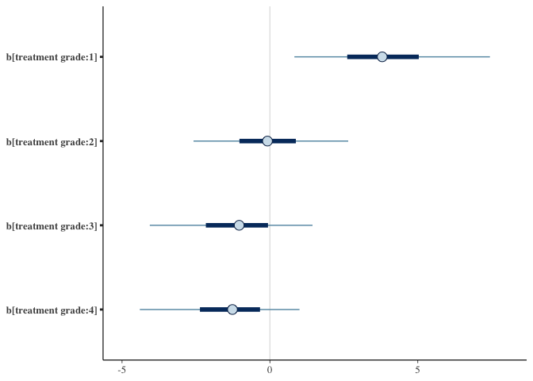

- Predictions:

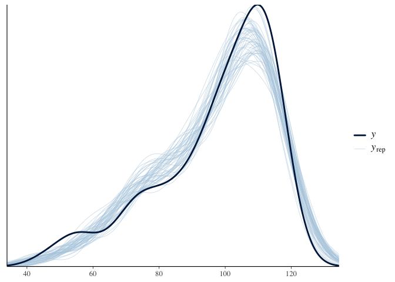

The hierarchical model makes narrower predictions around has true values of the target variable. This model also suggests that the treatment effect is primarily evident in first-grade students. This observation is likely due to the increasing homogeneity and reading proficiency levels among students in higher grades, diminishing the potential impact of the treatment.